# Ejercicio 1

Franco Saravia

2025-08-22

Para esta actividad, primero se lee el archivo csv que contiene los datos públicos recopilados por la encuesta Casen 2017 en la Región Metropolitana.

```
## [1] 0
```

```
## [1] 0
```

Primero debemos darnos cuenta cual es el tipo de variable por el que se nos pregunta. Para comenzar se tiene que la variable de ingresos es numérica discreta y pertenece a los números enteros no negativos (cardinales). Luego se tiene la variable provincias, la cual es categórica nominal.

Para saber si los ingresos en distintas provincias de la Región Metropolitana son similares, se pueden usar las siguientes medidas estadísticas: Por parte de las medidas de tendencia central se van a usar la media aritmética y la mediana, se eligieron estas debido a que se pueden comparar los ingresos promedio y el o los datos centrales entre provincias para verificar la similitud de ingresos. Por parte de las medidas de dispersion se van a usar la desviación estándar y el IQR (rango intercuartil), estos se usan para darle más peso a las medidas de tendencia central, ya que una menor desviación estandar y un menor IQR indican que los ingresos no varian mucho y, por ende, tenderian a ser más similares.

Por otra parte, el grafico más conveniente para mostrar si los ingresos son similiares o no es el grafico de violin, esto debido a que son especialmente utilies para comparar distribuciones entre varios grupos, que es justamente lo que queremos hacer, ya que además de tener el grafico de caja, tienen la distribucion de los graficos de linea, haciendo podible ver tambien la distribución de los datos.

Continuando, comenzaremos a realizar las mediciones, primero se realizarán las mediciones de la media aritmetica, la mediana, la desviación estandar y el IQR

```
##    provincia    Media Mediana desviación_Estandar Rango_Intercuartil
## 1  Chacabuco 436132.0  308387            699789.4           363513.0
## 2 Cordillera 410705.2  307425            487472.9           370230.8
## 3      Maipo 337054.6  280000            367832.1           322136.5
## 4  Melipilla 295947.6  244583            308643.6           282922.0
## 5   Santiago 692506.5  370000           1365242.4           525369.0
## 6  Talagante 378577.3  275000            523756.9           353838.2
```

Despues de ver los estadísticos, se crea el grafico de violin respectivo para corroborar los datos entregados por las medidas anteriores

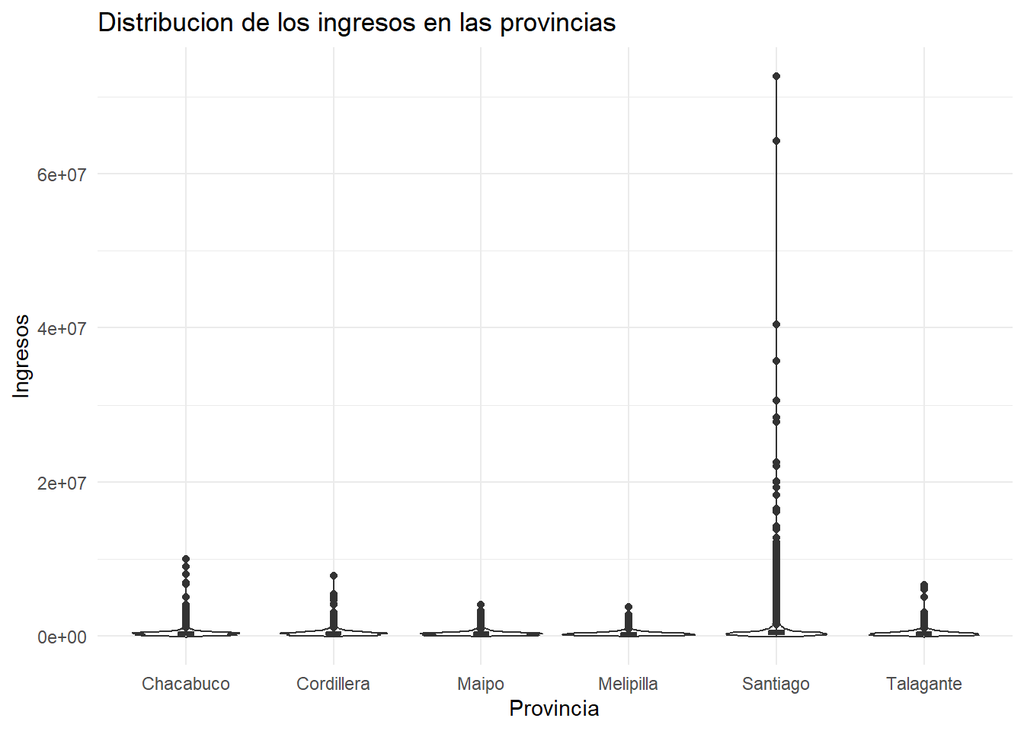

Lo más notable al ver el grafico es la diferencia entre todas las provincias de la region metropolitana y la provincia de Santiago, donde esta ultima a simple vista presenta observaciones desproporcionadamente más grandes que el resto de provincias, teniendo algunos datos mayores a 20 millones de pesos.

### Conclusión

A pesar de que tanto las medidas estadísticas como el gráfico muestran que los salarios de las distintas provincias de la RM son distintos, no es posible asegurar nada. Para poder llegar a una conclusión acertada, es necesario realizar pruebas estadísticas más eficaces. Sin embargo, este análisis sirve como un buen comienzo para otra investigación más profunda.

Como ya se dijo, este análisis sirvió como un vistazo inicial, más no para una conclusión seria. Para continuar esta investigación es más recomendable usar otros métodos más seguros: en vez de usar análisis descriptivo, usar métodos inferenciales, como alguna prueba entre las distintas provincias.